# Daniella Fierro

## 👋 About Me

I have close to five years of experience across HR analytics, change management, and systems implementation, with a background spanning both generalist and specialist HR roles. My experience sits at the intersection of people, systems, and data, which has developed a strong interest in how these areas can work together to support better decision-making and improve organisational outcomes.

Throughout my previous roles, I worked with workforce and payroll data across multiple systems to improve reporting accuracy, streamline processes, and provide insights to support organisational initiatives and operational decisions. This included developing Power BI dashboards, analysing employee engagement survey data, and preparing workforce reporting that informed initiatives related to workforce planning, DEI, employee experience, and organisational change.

Working across both HR and data has shaped a practical and insight-driven approach to problem solving. I’m naturally curious and enjoy exploring new ways of doing things, seeking different perspectives, challenging assumptions, and continuously improving how data is used to inform outcomes. I have developed an appreciation for the importance of accuracy and attention to detail when working with data, particularly where it supports decision-making and communication across teams and stakeholders.

Motivated by this interest, I completed a Graduate Certificate in Data Science and am currently enrolled in a Master of Science in Health Data Science, pending commencement in September 2026. Alongside formal study, I continue to build my analytical capability through university and personal projects using R and Power BI, with a focus on statistical analysis, data visualisation, and reporting. I also enjoy working through complex or unfamiliar problems and see continuous learning as a core part of my development.

This site highlights a selection of my projects, experience, and ongoing learning as I continue building my skills in analytics, reporting, and data-driven problem solving.

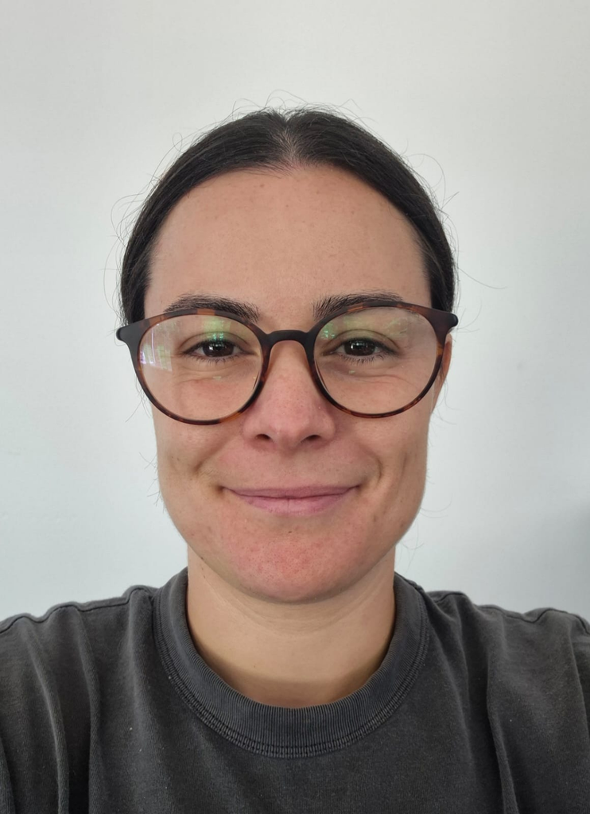

### 📫 Contact

✉️Email

🔗[LinkedIn](https://www.linkedin.com/in/daniellafierro)

💻[GitHub](https://github.com/RubenPuben7)

## 🧠 Skills

**Analytics** - R (dplyr, ggplot2) - Power BI (Data Visualisation)

**HR & Systems** - HRIS & Workforce Data - Change Management - Systems Implementation

**Other** - Excel - Reporting & Insights - Stakeholder Engagement

## 📊 Featured Work

### 📈 HR Analytics Dashboard

Power BI dashboard analysing workforce trends, attrition, tenure and pay.

🔗 [View Project](https://github.com/RubenPuben7/hr-analytics-dashboard-2026)

### 📉 Livestock Trends (R Analysis)

TidyTuesday project exploring livestock trends using R and Quarto.

🔗 View Analysis

## 🚀 What I’m Working On

- Expanding capability in **statistical analysis (R)**
- Building **end-to-end analytics projects**
- Strengthening **data storytelling and reporting**

## Professional Experience

**Casual Marker - Foundations of Biostatistics**  
UNSW, July 2025 – August 2026

- Assess student assignments, applying marking criteria consistently
- Provide clear, constructive feedback to support student learning in core statistical concepts such as hypothesis testing, confidence intervals, and data interpretation.
- Collaborate with course coordinators to clarify marking standards and ensure consistency across student cohorts

**Business Consultant**  
Zero:100 Consulting, October 2023 – January 2025

- Designed new policies and processes personalised to clients to improve HR practices and project delivery.
- Enhanced UI/UX through WordPress.

**People & Culture Officer**  
A-Leagues (APL), January 2022 – October 2023

**HR Analytics:**

- Designed and managed an **HR Metrics Dashboard via Power BI**, integrating JavaScript customizations to align with APL branding and providing insights on workforce demographics, turnover, and DEI initiatives.
- Designed and led the complete **Employee Engagement Project**, from survey creation, delivery, results analysis, and recommendations. These recommendations dramatically shaped the working approach, recruitment initiatives and overall structure at the A-leagues.

**Project Leadership:**

- Led two relocation projects, delivering within a tight timeframes and earning senior leader commendation.

**HR Infrastructure:**

- Established automated processes for onboarding/offboarding, enhancing operational efficiency and drafted policy to support various HR workflows.
- Developed a successful **internship program** that enabled students a professional pathway into the A-Leagues. Nalin Mastou was our first female intern, later hired and now a well-recognised sports reporter, writer and social media producer in a predominantly male dominated field.

**Workforce Analyst Au/NZ**  
Zimmer Biomet Au/NZ, November 2019 – December 2021

**Systems Deployment:**

- Led the payroll and time/attendance system data migrations, which included:
- Align data from the internal payroll system to ADP
- Accurately configure HR systems for correct data flow, set up workflows and troubleshoot bugs
- Developing comprehensive training materials and conducting info/training sessions for employees and leaders

**Payroll & Reporting:**

- Managed all things payroll for Australia and New Zealand, from processing to payment, and all pay related queries, i.e. interpretation of policy/awards
- Produced reports on leave liabilities, WGEA, headcount, and compensation trends.

## Education

| Masters of Science in Health Data Science — 2028 |
| --- |
| Graduate Certificate, Data Science — 2025 |
| Lean Six Sigma Green Belt Certification —2022 |
| Bachelor of Commerce, Human Resources — 2018 |

## Other Experience/Volunteering

| Australian Female Football Association | Vice - President | March 2026 - Current |
| --- | --- | --- |
| Phoenix Caulking | Director | May 2025 - Current |
| Western Condors FC | Grant Writing | March 2025 - Current |
| Strathfield Strikers FC | Football Coach | 2021 |
| Shining Light Foundation | Casual Volunteer | 2018 |